# Measuring Euro Area monetary policy: going beyond monetary surprises

# Theoretical Foundation

Figure 1 shows a stylized comparison between a monetary surprise a-la Altavilla and a combined monetary and monetary policy uncertainty surprise.

In the left panel, before the governing council,the distribution of OIS quotes is centered around 0 and has a unit standard deviation. After the meeting, the distribution shifts to the right, centering at 1; this movement coincides with a tightening of the mean OIS rate.

In the right panel, instead, not only the mean of the distribution shifts to right after the governing council, but its variance also increases. Although agents revised their expectation, there is more heterogeneity concerning the future path of the rate, with different agents betting on different movements of the aforementioned.

The two cases could have very different implications for the behaviour of financial variables (e.g. stock prices, exchange rates, etc.) and trasmission of monetary policy (sovereign yields), and thus for real variables such as credit, output and inflation. In principle, one would expect uncertainty to hamper the effect of monetary surprises, hence hindering ECB decided policies.

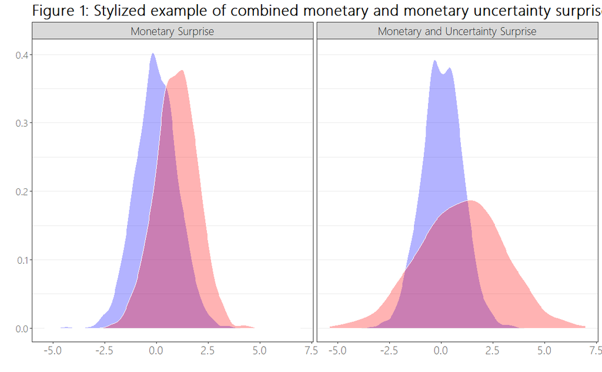